# Synthetic data

Zulato Davide

2022-11-02

## BIASED DATA

Simulating Data: L’idea è di introdurre una Sensitive Feature $S$, (nella notazione letteratura), Variabile Target $Y$ e un insieme di Variabili indipendenti $X$. ricorda di integrare pasadosso di Simpson e verificare che il classificatore sia BIASED.

Utilizzo l’approccio classico per generare i dati, in alternativa è possibile utilizzare il pacchetto “simstudy”.

```r
# Libraries
library(ggplot2)
library(ggpubr)
library(hrbrthemes)
library(dplyr)
library(tidyr)
library(viridis)
library(simstudy)
library(MASS)
library(tidyverse)
library(tikzDevice)
library(data.table)
```

## Synthetic Data

Definizione delle variabili e delle distribuzioni iniziali

numerosità del campione che voglio generare

```r
n <- 10000
set.seed(876101)
```

per la variabile età si potrebbe estrarre da una normale di media 26 e varianza 1.5, l’idea è di osservare un campione di individui tra i 21 e i 30 anni. In alternativa ho estratto da un chi-quadrato con 0.5 gdl per ottenere una distribuzione asimmetrica dell’età a cui sommo l’età “minima” (plausibile se il campione è estratto tra neo-laureati). L’età è stata generata indipendentemente da $S$, ma una distribuzione asimmetrica potrebbe portare, come descritto dalla letteratura, ad un bias nei confronti dei più anziani, poichè l’algoritmo, in fase di training, osserverebbe pochi esempi.

```r
# age <- rnorm(n,26,sqrt(1.5))
# min(age); max(age)

age <- 22+rchisq(n,0.5) # sommo molti valori prossimi a zero
summary(age)
```

```
##    Min. 1st Qu.  Median    Mean 3rd Qu.    Max.
##   22.00   22.01   22.08   22.50   22.51   37.11
```

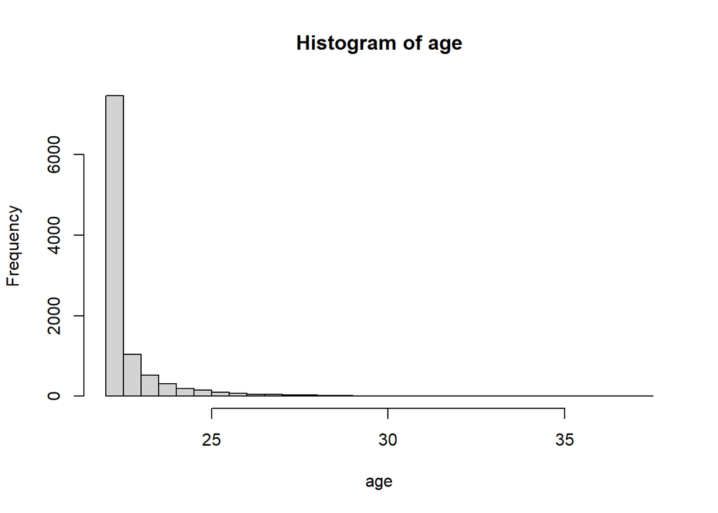

```r
hist(age,breaks=50)
```

```r
# boxplot(age) # may too many outliers
```

Definisco indipendentemente la variabile protetta $S$ estraendo da una binomiale con probabilità di successo $\pi=0.2$; sarà quindi, in questo esempio, un campione composto dal 20% di donne. L’idea è di emulare una situazione reale (e.g. area STEM) all’interno della quale il training set presenta una classe protetta sbilanciata e l’algoritmo utilizzato per la previsione potrebbe portare reiterare BIAS presente nei dati.

```r
S <- rbinom(n,1,0.2)
table(S) # 20% donne
```

```
## S
##    0    1
## 7928 2072
```

Definisco una variabile di conteggio, con distribuzione di Poisson con media che dipende da età e genere ad indicare un ipotetico numero di colloqui sostenuti, l’idea è che $\lambda$, media e varianza della Poisson sia legata (Positivamente) con la dummy “female” e con l’età.

$$\begin{equation}
interview ~ Po(\lambda)
\end{equation}$$

$$\begin{equation}
\lambda=f(S,Age,\eta)
\end{equation}$$

```r
lambda <- 1.5 + 0.2 * age + 1.5 * S + rnorm(1) # rumore white noise
interview <- rpois(n,lambda = lambda)
summary(interview)
```

```
##    Min. 1st Qu.  Median    Mean 3rd Qu.    Max.
##   0.000   4.000   6.000   5.721   7.000  19.000
```

```r
cor(interview,S)
```

```
## [1] 0.2440457
```

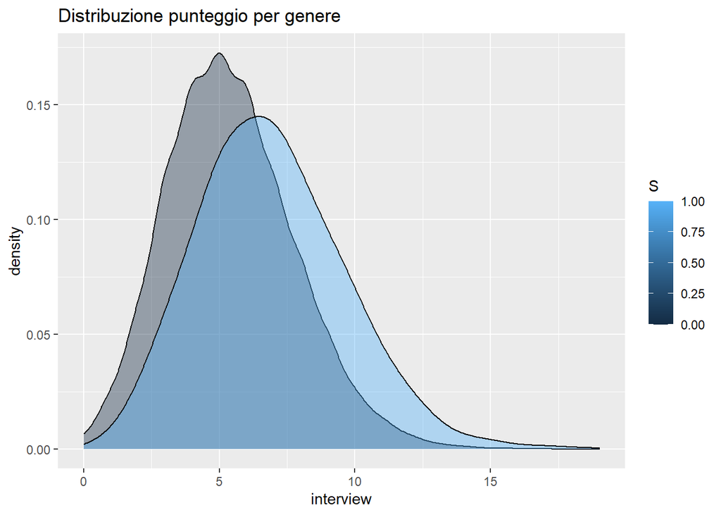

```r
dd <- as.data.frame(cbind(S,interview))

p1 <- ggplot(data=dd, aes(x=interview, group=S, fill=S),col=c(3,4)) +
  geom_density(adjust=1.5, alpha=.4) +
  ggtitle("Distribuzione punteggio per genere")
p1
```

Creo una variabile che sia Proxy di $S$, ad esempio, account github.com (questa proxy potrebbe non essere valida in area STEM poichè ci aspettiamo che dipenda dal percorso di studi piuttosto che dal genere). Questa proxy dovrà essere poi legata all’outcome. Reminder: i coefficienti del modello logit NON rappresentano gli effetti marginali ma il segno conta. (Manera, Microeconometria)

```r
set.seed(876101)
z = 1-0.7*S+rnorm(1)        # linear combination with a bias
pr = 1/(1+exp(-z))         # pass through an inv-logit function
Github_account = rbinom(n,1,pr)      # bernoulli response variable

# relation with S e prop.table per riga
table(S, Github_account); round(prop.table(table(S, Github_account),1),2)
```

```
##    Github_account
## S      0    1
##   0 4824 3104
##   1 1593  479
```

```
##    Github_account
## S      0    1
##   0 0.61 0.39
##   1 0.77 0.23
```

```r
round(prop.table(table(S, Github_account),2),2)
```

```
##    Github_account
## S      0    1
##   0 0.75 0.87
##   1 0.25 0.13
```

```r
# tra i possessori di un account Github ~13% donne, sottorappresentate
# tra le donne 23% ha account vs il 39% degli uomini

#now feed it to glm:
df = data.frame(Github_account,S)
glm(Github_account ~S,data=df,family="binomial")
```

```
##
## Call:  glm(formula = Github_account ~ S, family = "binomial", data = df)
##
## Coefficients:
## (Intercept)            S
##     -0.4409      -0.7608
##
## Degrees of Freedom: 9999 Total (i.e. Null);  9998 Residual
## Null Deviance:       13050
## Residual Deviance: 12860     AIC: 12860
```

Si noti che è sufficiente cambiare il coefficiente (in particolare il segno) associato ad una Sensitive feature o a una sua proxy per cambiare sensibilmente i valori di output

```r
mu <- 3*S+rnorm(1) # linear combination + noise
proxy <- (rnorm(n,mu,2))
summary(proxy)
```

```
##    Min. 1st Qu.  Median    Mean 3rd Qu.    Max.
## -6.6819 -0.5325  1.0279  1.1201  2.6512 10.1963
```